# CURSO DE ACTUALIZACION EN ESTADISTICA

#### Profesor: Dr. José Manuel MAGALLANES, Ph.D

## Sesión 8:

## **Medidas de Asociación Categórico Numérica**

Cuando tenemos una variable categórica y otra numérica queremos saber la relación entre estas, es decir, si los valores de la nuérica varían según el nivel de la categórica.

Traigamos la data del formato1:

```r
# link a google:
lk="https://docs.google.com/spreadsheets/d/e/2PACX-1vRPPixYG_1dwhr8nQW-8VHq5Fel6s7ftYpiMYt_ZIcKdU3ZCa-x8D0Nkc9ojTVpmHkGkbclq5sHJLGK/pub?gid=0&single=true&output=csv"

# colectando datos
presupuesto=read.csv(lk,stringsAsFactors = F)
```

Veamos cómo se trajo la data:

```r
str(presupuesto)
```

```
## 'data.frame':    30 obs. of  12 variables:
##  $ sector        : chr  "01: PRESIDENCIA CONSEJO MINISTROS" "03: CULTURA" "04: PODER JUDICIAL" "05: AMBIENTAL" ...
##  $ sectorn       : chr  "PCM" "CUL" "PJ" "AMB" ...
##  $ pim2016G      : num  2.02e+09 5.43e+08 2.12e+09 6.49e+08 1.74e+09 ...
##  $ devengado2016G: num  1.70e+09 4.88e+08 2.09e+09 5.25e+08 1.49e+09 ...
##  $ girado2016G   : num  1.70e+09 4.87e+08 2.08e+09 5.24e+08 1.49e+09 ...
##  $ pim2016I      : num  1.13e+09 2.28e+08 2.46e+08 3.70e+08 8.57e+08 ...
##  $ Recaudado2016 : num  1.39e+09 2.70e+08 2.48e+08 3.96e+08 9.77e+08 ...
##  $ pim2018G      : num  7.24e+09 6.19e+08 2.49e+09 6.82e+08 2.17e+09 ...
##  $ devengado2018G: num  5.30e+09 5.84e+08 2.38e+09 6.24e+08 1.73e+09 ...
##  $ girado2018G   : num  5.30e+09 5.83e+08 2.38e+09 6.24e+08 1.73e+09 ...
##  $ pim2018I      : num  3.13e+09 2.56e+08 2.94e+08 3.48e+08 9.17e+08 ...
##  $ Recaudado2018 : num  2.70e+09 4.07e+08 3.20e+08 4.29e+08 8.76e+08 ...
```

Veamos la media de las columnas relacionadas con gasto del 2018 (pim, devengado y girado):

```r
apply(presupuesto[,c(8:10)],2,mean) # 2 indica calcular en vertical (por columna)
```

```
##       pim2018G devengado2018G    girado2018G
##     3725154810     3354586705     3350598926
```

Podemos preguntarnos si la diferencia entre ellas es significativa, asumiendo que estos es una muestra del gasto en too el estado en 2018. Pero necesitamos darle un formato tipo 2 a la data:

```r
dataTest=stack(presupuesto[,c(8:10)])

# veamos:

dataTest
```

```
##         values            ind
## 1   7241596982       pim2018G
## 2    619462643       pim2018G
## 3   2487324456       pim2018G
## 4    681740039       pim2018G
## 5   2166955714       pim2018G
## 6  11296451326       pim2018G
## 7    887225987       pim2018G
## 8  23817079535       pim2018G
## 9  11752676269       pim2018G
## 10  9370578946       pim2018G
## 11   519227956       pim2018G
## 12  2802674788       pim2018G
## 13  1656481662       pim2018G
## 14   669586761       pim2018G
```

[output cut: 76 more lines]

Notese que el formato 2 produce la categoría:

```r
str(dataTest)
```

```
## 'data.frame':    90 obs. of  2 variables:
##  $ values: num  7.24e+09 6.19e+08 2.49e+09 6.82e+08 2.17e+09 ...
##  $ ind   : Factor w/ 3 levels "pim2018G","devengado2018G",..: 1 1 1 1 1 1 1 1 1 1 ...
```

Ahora, hipoteticemos que las medias de estas variables no son diferentes.

Primero veamos gráficos:

- Visualizar con histograma:

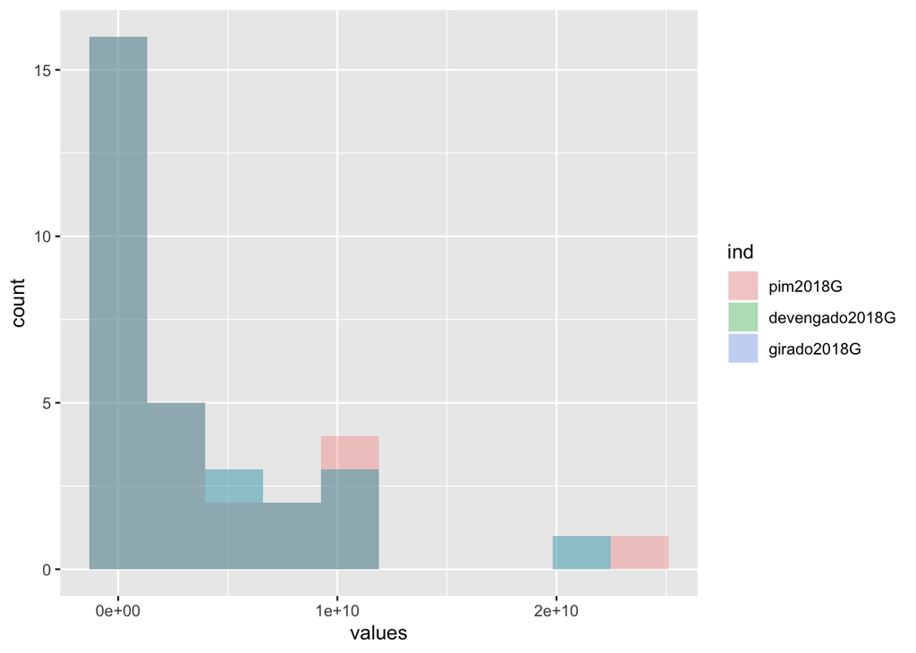

```r
library(ggplot2)
ggplot(dataTest, aes(x=values, fill=ind)) +
    geom_histogram(bins=10, alpha=.3, position="identity")
```

Como hay mucho traslape, parece que nuestra hipotesis es cierta.

- Usemos el boxplot:

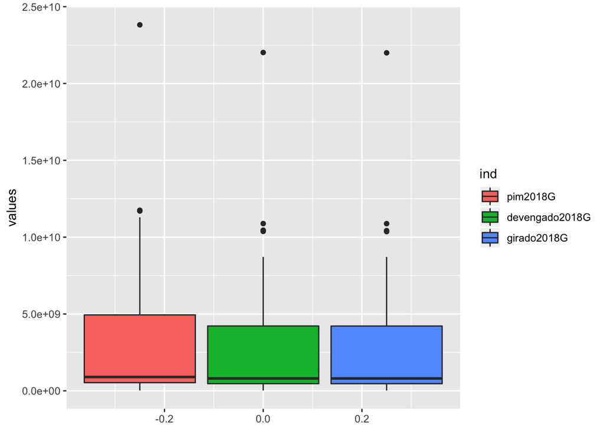

```r
ggplot(dataTest, aes(y=values, fill=ind)) + geom_boxplot()
```

Parce respaldar lo anterior, hagamos uso de las probabilidades en R.

## Prueba de Hipótesis

### Alternativa paramétrica:

Habrá variación en promedio?

```r
summary(aov(values~ind, data=dataTest))
```

```
##             Df    Sum Sq   Mean Sq F value Pr(>F)
## ind          2 2.776e+18 1.388e+18   0.053  0.948
## Residuals   87 2.261e+21 2.599e+19
```

### Alternativa no-paramétrica:

Por este camino obtendríamos algo similar:

```r
kruskal.test(values~ind, data=dataTest)
```

```
##
##  Kruskal-Wallis rank sum test
##
## data:  values by ind
## Kruskal-Wallis chi-squared = 0.42171, df = 2, p-value = 0.8099
```

**Ejercicio:**

Utilice sus datos y calcule las medidas que correspondan.

[Volver al programa del curso](https://coursesandtutorials.github.io/Estadistica/)